# Relationships among Personality Traits by Damian Satterthwaite-Phillips

## Using a Model to Make Predictions

As one last study, lets suppose that a company is able to infer most personality traits based on other evidence (cognition based on test scores, conscientiousness based on social activities, empathy based on responses on Facebook, or whatever…), but introversion/extroversion cannot be easily estimated. However, certain types of work may be more appropriate for introverts, and other types for extroverts, so the company wishes to estimate extroversion/introversion based on the other available data. How well can this goal be achieved with the tools we have learned so far?

First, to simplify, let's try to normalize all of our numeric variables To acheive this, write a simple function that transforms the data with a range of exponent values, checks the normality for each, and reports on the optimal transformation NOTE: sometimes other functions may be more appropriate for normalizing, but exponents work in many cases… in some cases, no (continous) normalizing function can be easily found.

```r
# Transform a vector x of values with a range of exponential transformations, and return the optimal
# exponent from those within the range tested
# @param x: vector of raw data values
# @param minExp: minumum exponent value to be tested
# @param maxExp: maximum exponent value to be tested
# @param step: interval between exponent values to be teste
# @param samples: Because shapiro.test() only allows a maximum length of x of 5000, we do repeated
#                 samplings from x and average the p value results from shapiro.test.  This parameter
#                 indicates the number of such samplings that should be carried out.
# @return: the exponent that gave the optimal transformation (highest p value from the Shapiro-Wilk
#          test), over the range of values tested
optimumExponent <- function(x, minExp=-2, maxExp=2, step=0.01, samples=20) {
    exps <- seq(minExp, maxExp, step)
    # remove 0 as a base taken to the 0th power is undefined:
    if (0 %in% exps) {
        exps <- exps[-which(exps==0)]
    }


    # initialize a vector, ps, that will store the p values of Shapiro-Wilk tests for normality for
    # each transformation
    ps <- numeric(length(exps))

    # loop through each exp value, transform, test for normality, and write results to ps
    for (e in 1:length(exps)) {
        xTrans <- x^exps[e]

        # Unfortunately, the shapiro.test function will allow a maximum sample size of 5000, so we
        # take random samples, and average the results
        pSets <- numeric(samples)

        for (s in 1:samples) {
            pSets[s] <- shapiro.test(sample(xTrans, size=5000))$p.value
        }

        ps[e] <- mean(pSets)

    }

    plot(ps ~ exps, type='l', xlab='Exponent', ylab='p Value')
    # because of the random sampling, the output is jagged, rather than the expected smooth, continous
    # function... (smoothness improves as 'samples' increases)

    bestP <- max(ps)
    bestPIndex <- which(ps == bestP)
    bestExp <- exps[bestPIndex]

    abline(v=bestExp, col=2)
    legend('topleft', pch='', legend=paste('Best Exp: ', bestExp, ' (p = ', round(bestP, 3), ')'))
    return (bestExp)
}
```

Apply transformations, and visualize transformed data as histograms

```r
 names(big5)
```

```
 ##  [1] "race"     "age"      "engnat"   "gender"   "hand"     "source"
 ##  [7] "country"  "E1"       "E2"       "E3"       "E4"       "E5"
 ## [13] "E6"       "E7"       "E8"       "E9"       "E10"      "N1"
 ## [19] "N2"       "N3"       "N4"       "N5"       "N6"       "N7"
 ## [25] "N8"       "N9"       "N10"      "A1"       "A2"       "A3"
 ## [31] "A4"       "A5"       "A6"       "A7"       "A8"       "A9"
 ## [37] "A10"      "C1"       "C2"       "C3"       "C4"       "C5"
 ## [43] "C6"       "C7"       "C8"       "C9"       "C10"      "O1"
 ## [49] "O2"       "O3"       "O4"       "O5"       "O6"       "O7"
 ## [55] "O8"       "O9"       "O10"      "EScore"   "NScore"   "AScore"
 ## [61] "CScore"   "OScore"   "ageTrans"
```

```r
 ageExp <- optimumExponent(big5$age, minExp=-2, maxExp=2, samples=50)
```

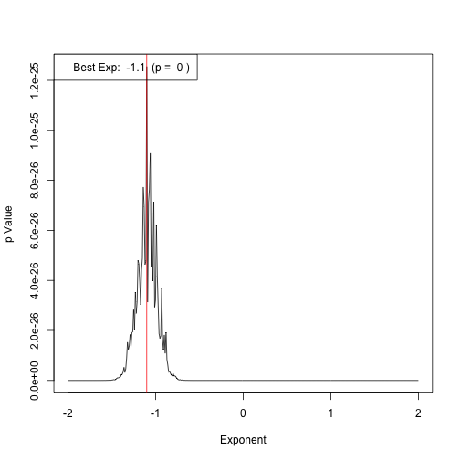

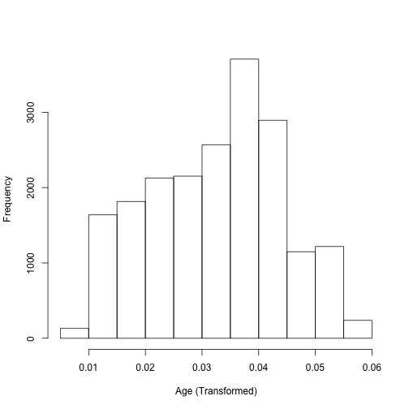

```r
 big5$ageTrans <- big5$age^ageExp
 hist(big5$ageTrans, main='', xlab='Age (Transformed)')
```

```r
 EExp <- optimumExponent(big5$EScore, minExp=-2, maxExp=2, samples=50)
```

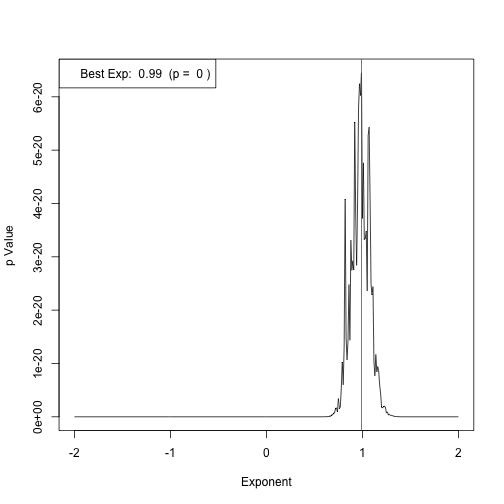

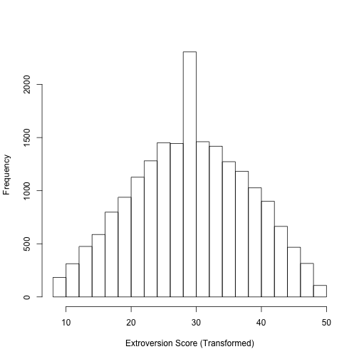

```r
 big5$ETrans <- big5$EScore^EExp
 hist(big5$ETrans, main='', xlab='Extroversion Score (Transformed)')
```

```r
 NExp <- optimumExponent(big5$NScore, minExp=-2, maxExp=2, samples=50)
```

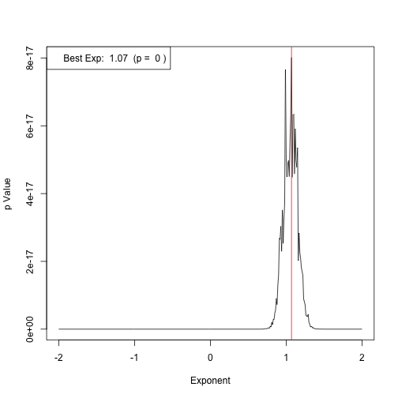

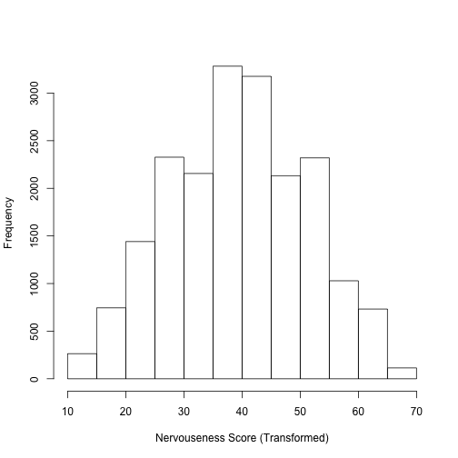

```r
 big5$NTrans <- big5$NScore^NExp
 hist(big5$NTrans, main='', xlab='Nervouseness Score (Transformed)')
```

```r
 AExp <- optimumExponent(big5$AScore, minExp=0, maxExp=4, samples=50)
```

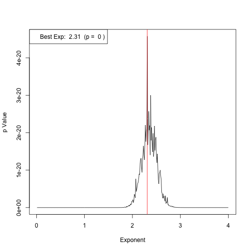

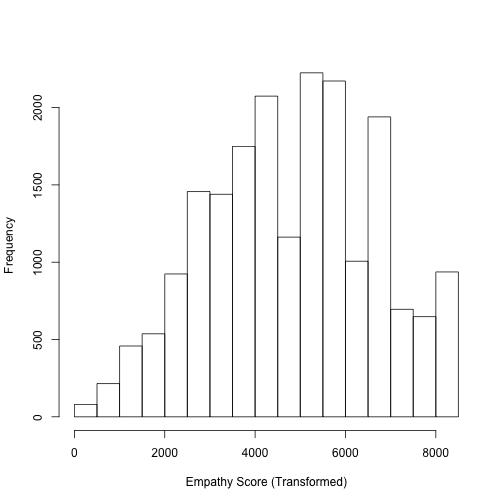

```r
 big5$ATrans <- big5$AScore^AExp
 hist(big5$ATrans, main='', xlab='Empathy Score (Transformed)')
```

```r
 CExp <- optimumExponent(big5$CScore, minExp=-2, maxExp=2, samples=50)
```

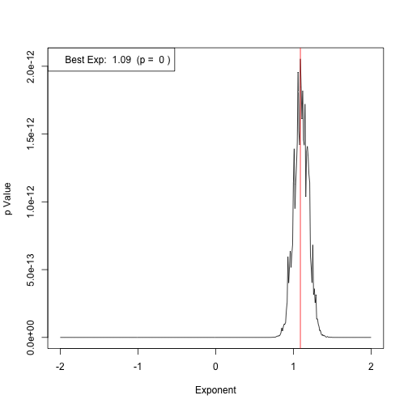

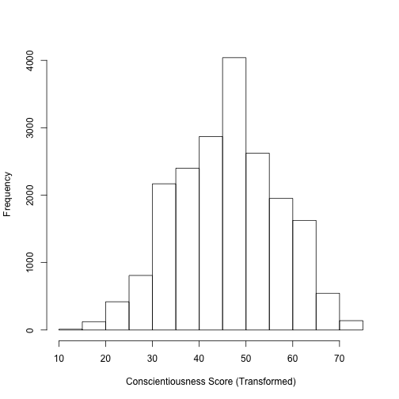

```r
 big5$CTrans <- big5$CScore^CExp
 hist(big5$CTrans, main='', xlab='Conscientiousness Score (Transformed)')
```

```r
 OExp <- optimumExponent(big5$OScore, minExp=0, maxExp=4, samples=50)
```

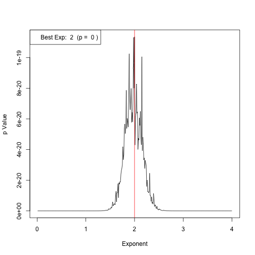

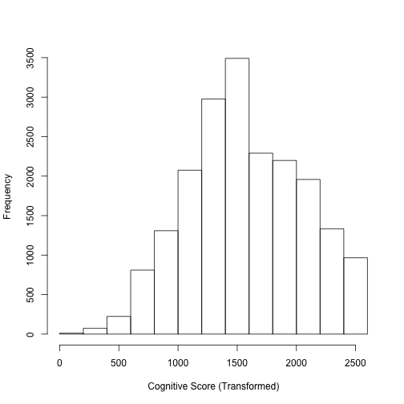

```r
 big5$OTrans <- big5$OScore^OExp
 hist(big5$OTrans, main='', xlab='Cognitive Score (Transformed)')
```

NOTE: although the normality of the distributions were improved, in NO case were they truly normalized very well (all p values were still highly significant for Shapiro-Wilk tests, indicating significantly non-normal distributions)… hence non-parametric tests might typically be prefered, but for the sake of demonstration, I proceed with the transformed variables.